# Lab 5: Binary Outcome Models

Mateo Villamizar Chaparro

Sept 18, 2020

## **Conducting Wald Tests**

```r
library(WDI)                                      # Calls a package where we can download WDI ndicators

# Some data wrangling
wdi.df <- WDI(country = "all",
              indicator = c("SM.POP.TOTL.ZS",     # Refugees as a percentage of the population
                            "NY.GDP.PCAP.PP.CD",  # GDP per capita
                            "NE.EXP.GNFS.ZS",     # Exports
                            "SE.XPD.CTOT.ZS",     # Education expenditure
                            "SH.XPD.CHEX.GD.ZS"), # Health expenditure
              start = 2015,
              end = 2015, extra=T)                # The extra just add some addiitonal identifying variables

wdi.df <- subset(wdi.df, region != "Aggregates")
wdi.df <- na.omit(wdi.df)
names(wdi.df)[4:8] <- c("p_refugees", "gdp", "exports", "exp_educ", "exp_health")

# Some models we want to choose from
m2 <-  glm(log(p_refugees) ~ log(gdp) + exports + exp_health + exp_educ, family = gaussian(link = "identity"), data = wdi.df)
```

### Wald Test

2. The more general case

Here we want to calculate the Wald test in a more general way. This means construct it in a way where we could be able to conduct multiple tests at the same time. The model we are studying right now is m2, which contains 5 parameters $\hat\theta=[\hat\theta_0\quad\hat\theta_1\quad\hat\theta_2\quad\hat\theta_3\quad\hat\theta_4]$. The intercept and the four right hand side variables. Now, we are going to use the wald test to test the following linear restrinctions:

- $\theta_1=0.1$
- $\theta_3 + \theta_4=0.5$

Which in plain English say that the effect of 1% change of the GDP per capita is correlated with a 0.1% increase in the percentage of refugees. Similarly, the second restriction implies that the sum between the expenditure in health and education is 0.5. We can construct a system of equations with the given information.
$$R = \begin{bmatrix} 0 & 1 & 0 & 0 & 0 \\ 0 & 0 & 0 & 1 & 1 \end{bmatrix}; \quad r=\begin{bmatrix} 0.1 \\ 0.5 \end{bmatrix}$$
And thus we can represent our linear restrictions as $R\hat\theta=r$. For the test, we would like to compare the following hypothesis (where $\hat\theta$ is a vector of estimated coefficients):

$H_o: R\hat\theta - r =0$

$H_a: R\hat\theta - r \neq 0$

The estimate we need to calculate is:
$$W = (R\hat\theta - r)'(R(\hat V)R')^{-1}(R\hat\theta - r) \sim \chi^2_{(h)}$$
Where $h$ is the number of restrictions

```r
R <- matrix(c(0,1,0,0,0,0,0,0,1,1), 2,5)                         # Constructing the R matrix
r <- matrix(c(0.1,0.5), 2, 1)                                    # Constructing the r vector
thetas <- coef(m2)                                               # Calling the coeeficientes from model 2
V <- vcov(m2)                                                    # Calling the variance covariance matrix
W <- t(R%*%thetas-r) %*% solve(R%*%V%*%t(R)) %*% (R%*%thetas-r)  # calculating the Wald statistic
pchisq(W, 2, lower.tail = F)                                     # Compare W with a chisq distribution with 2 df
```

```
##              [,1]
## [1,] 4.004095e-28
```

### Score Test

This is another test to evaluate MLE models. In this case, it tests the difference between the slopes of tangent lines between the estimate and the value we want to test it against. The null hypothesis here implies that the slopes are the same.This is a less common test.

$H_o: \hat\theta_j - \theta^* =0$

$H_a: \hat\theta_j - \theta^* \neq 0$

The estimate we need to calculate is:
$$ST = \frac{S(\theta_j)}{\sqrt{\mathscr{I}(\theta_j)}} \sim N(0,1)$$

## **Binary Outcome Models**

These types of models are constructed to analyze the correlation between a binary dependent variable and some explanatory variable(s). OLS is not well suited to deal with this types of dependent variables because of three things:

- Non-sensical predictions
- Heteroskedastic errors
- Assumes the relationship between the probability and a covariate is constant

Let’s look at some of them in R using the turnout dataset.

### The Linear Probability Model (LPM)

The LPM will use OLS to find the relationship between our binary outcome and the covariates.

```r
mlpm <- lm(voted ~ female + age + edu + informed, data = turnout)

# The probability is constant
summary(mlpm)
```

```
##
## Call:
## lm(formula = voted ~ female + age + edu + informed, data = turnout)
##
## Residuals:
##      Min       1Q   Median       3Q      Max
## -1.01044  0.01104  0.15941  0.24766  0.60988
##
## Coefficients:
##             Estimate Std. Error t value Pr(>|t|)
## (Intercept) 0.158121   0.067196   2.353  0.01880 *
## female      0.070545   0.025014   2.820  0.00489 **
## age         0.004965   0.000750   6.619 5.69e-11 ***
## edu         0.048297   0.012850   3.759  0.00018 ***
## informed    0.089375   0.016486   5.421 7.31e-08 ***
## ---
## Signif. codes:  0 '***' 0.001 '**' 0.01 '*' 0.05 '.' 0.1 ' ' 1
##
## Residual standard error: 0.3938 on 1073 degrees of freedom
## Multiple R-squared:  0.08012,    Adjusted R-squared:  0.07669
## F-statistic: 23.36 on 4 and 1073 DF,  p-value: < 2.2e-16
```

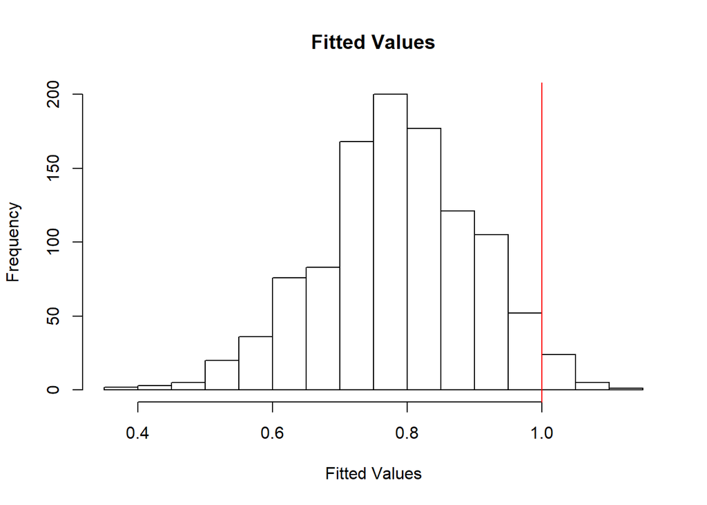

```r
# When calculating the fitted values we get values larger than one or smaller than zero.
hist(mlpm$fitted.values,
     main = "Fitted Values", xlab = "Fitted Values")
abline(v=1, col="red")
```

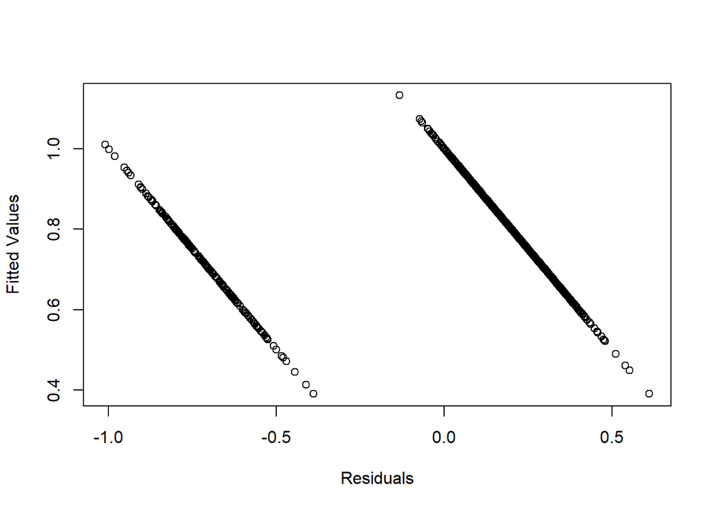

```r
# It is a heteroskedastic model (by construction)
plot(mlpm$residuals, mlpm$fitted.values,
     xlab = "Residuals", ylab = "Fitted Values")
```

The LPM could be useful under certain restricted circumstances, so it is not entirely a waste of time. If interested, see this [Heckman paper](https://www.jstor.org/stable/3087459?seq=1#metadata_info_tab_contents).

### The Logit Model

The logit model can be summarized by the following stochastic and systematic components
$$\begin{split}
Y &\sim Bernoulli(y_i|\pi_i) = \pi_i^{y_i}(1-\pi_i)^{1-y_i} \\
\\
\pi_i &= \Lambda(X_i\beta) = \frac{1}{1-e^{(-X_i\beta)}}
\end{split}$$
Where $\Lambda(X_i\beta)$ is the cummulative logistic function. Which results in the following likelihood function:
$$ll(\beta | y, x) = \sum^n_{i=1}\left[y_i\ln\Lambda(X_i\beta)+(1-y_i)\ln\Lambda(1-X_i\beta)\right]$$

Let’s calculate the MLE in R using the numerical approximation approach:

```r
#  Construct the covariates matrix and the outcome vector
X <- cbind(1, turnout$female, turnout$age, turnout$edu, turnout$informed)
y <- turnout$voted

# Create the likelihood function
ll_logit <- function(theta, y, X) {
  # Parameters
  beta <- theta[1:ncol(X)]
  # linear predictor
  mu <- X %*% beta
  # link function
  p <- 1/(1+exp(-mu))
  # log likelihood
  ll <- sum(y*log(p) + (1-y)*log(1-p))
  return(ll)
}

# maximize likelihood function numerically
StartingValues <- c(0,0,0,0,0)
res <- optim(par=StartingValues,       # starting values
             fn=ll_logit,              # the likelihood function
             y = turnout$voted,        # outcome variable
             X = X,                    # covariates
             method = "BFGS",          # optimization method
             control=list(fnscale=-1), # max instead of min
             hessian=TRUE)             # return Hessian matrix

# Let's see the results
results <- matrix(NA, ncol(X), 4)
results[,1] <- res$par
results[,2] <- sqrt(diag(solve(-1 * res$hessian)))
colnames(results) <- c("Estimate_hand", "SE_hand", "Estimate_canned", "SE_canned")
rownames(results) <- c("Intercept","Female", "Age", "Education", "Informed")
results
```

```
##           Estimate_hand     SE_hand Estimate_canned SE_canned
## Intercept   -2.49720684 0.428134702              NA        NA
## Female       0.42733941 0.162452518              NA        NA
## Age          0.03252833 0.005092639              NA        NA
## Education    0.34386180 0.088088438              NA        NA
## Informed     0.52161212 0.103152253              NA        NA
```

```r
# Compare the results with the glm function
mlog <- glm(voted ~ female + age + edu + informed,
            data = turnout,
            family="binomial")      # notice that last class this was different!
results[,3] <- mlog$coefficients
results[,4] <- diag(sqrt(vcov(mlog)))
results
```

```
##           Estimate_hand     SE_hand Estimate_canned   SE_canned
## Intercept   -2.49720684 0.428134702     -2.49461065 0.428159309
## Female       0.42733941 0.162452518      0.42736292 0.162438738
## Age          0.03252833 0.005092639      0.03247761 0.005093073
## Education    0.34386180 0.088088438      0.34343432 0.088079144
## Informed     0.52161212 0.103152253      0.52167461 0.103142851
```

So, the results are the same! But, how do we interpret them? Interpretation of logit and probit models is not that straightforward. Before diving down let’s see in R how the Probit and logit models are related.

### The Probit Model

```r
mprob <- glm(voted ~ female + age + edu + informed,
            data = turnout,
            family = binomial(link = "probit"))

comparison <- matrix(NA, 5, 3)
comparison[,1] <- mlog$coefficients
comparison[,2] <- mprob$coefficients
comparison[,3] <- mlog$coefficients/(pi/sqrt(3))
colnames(comparison) <- c("Logit", "Probit", "Logit/1.81")
rownames(comparison) <- c("Intercept","Female", "Age", "Education", "Informed")
comparison
```

```
##                 Logit      Probit  Logit/1.81
## Intercept -2.49461065 -1.40955405 -1.37535093
## Female     0.42736292  0.25267072  0.23561753
## Age        0.03247761  0.01841255  0.01790585
## Education  0.34343432  0.19368089  0.18934527
## Informed   0.52167461  0.30613414  0.28761429
```

## **Interpretation of Coefficients**

There are multiple quantities of interest that you might want to calculate. For this lab we are going to focus on three, the odds ratio, the log-odds ration, the predicted probability and the marginal effects.

### Odds ratio and log-odds ratio

```r
# Let's exponentiate the numerical results
exp(res$par)
```

```
## [1] 0.0823146 1.5331729 1.0330632 1.4103837 1.6847415
```

```r
# But also the glm results
exp(mlog$coefficients)
```

```
## (Intercept)      female         age         edu    informed
##  0.08252858  1.53320899  1.03301076  1.40978093  1.68484675
```

```r
# What is the relationship between being female and the probability of voting?
exp(mlog$coefficients["female"])
```

```
##   female
## 1.533209
```

However, one of the advantages of the logit model is that the probability is not constant but changes at different levels of the RHS variables. Which basically entail that we would need to calculate **conditional marginal effects**.

### Expected Value or Predicted Probability Approach

The expected value approach calculates the probability of a success, given certain characteristics of all the RHS variables. We can do this by using the “typical case” approach. Let’s see how to do it in R.

#### Typical Case Approach

For the typical case approach, we just set the independent variables we are interested in to certain values of interest and the other varaibles to central tendencies (measn, modes, medians, etc)

```r
# What is the probability that an 18 year old female, without education and uninformed about politics voted? There are three ways in R to do this:

# 1. Using the results from our MLE and the plogis command
# The plogis command just gives us the probability of the logistic distribution
plogis(c(1,1,18,0,1)                          # vector of values for the RHS vars ORDER MATTERS!!!!!
       %*% res$par)                           # vector of estimated coefficients
```

```
##           [,1]
## [1,] 0.2763289
```

```r
# 2. using the glm results
plogis(c(1,1,18,0,1) %*% coef(mlog))
```

```
##           [,1]
## [1,] 0.2766828
```

```r
# 3. using the predict command
predict(mlog,                                  # glm model
        newdata = data.frame(female = 1,       # values for the other RHS variables
                             age = 18,
                             edu = 0,
                             informed = 1),
        type = "response")                     # Tells the command we want predicted probabilities
```

```
##         1
## 0.2766828
```

```r
# What would be the probability of voting for the average individual?
# I think there is not a good Mode function in R, so let's use the following. Why would the mode be important?
Mode <- function(x) {
  ux <- unique(x)
  ux[which.max(tabulate(match(x, ux)))]
}

# Predicted probability of the average individual
predict(mlog,
        newdata = data.frame(female = Mode(turnout$female),
                             age = mean(turnout$age),
                             edu = mean(turnout$edu),
                             informed = Mode(turnout$informed)),
        type = "response")
```

```
##        1
## 0.827912
```

```r
# The probability of that a 45 year old female with some education and very informed about politics votes is 0.82.
```

## **Plotting Quantities of Interest**

### Predicted Probabilities

Let’s first plot the predicted probability

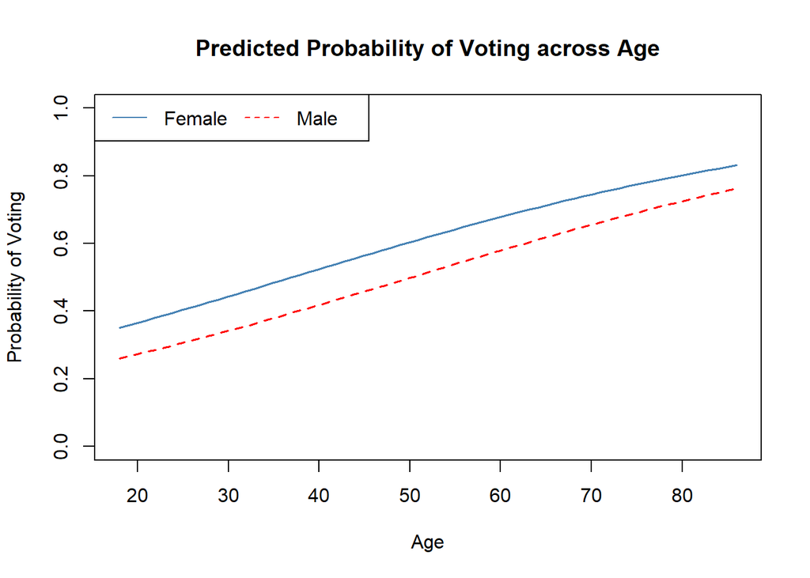

```r
# LEt's estimate the predicted values
x <- seq(18, 86, 1)
y_f <- predict(mlog, newdata = data.frame(age = x,
                                        female=1,
                                        edu=1,
                                        informed=1),
             type = "response")
y_m <- predict(mlog, newdata = data.frame(age = x,
                                        female=0,
                                        edu=1,
                                        informed=1),
             type = "response")

plot(x, y_f,
     lwd = 1.5, col = "steelblue", type="l",
     ylim = c(0, 1),
     main = "Predicted Probability of Voting across Age",
     xlab = "Age",
     ylab = "Probability of Voting")
lines(x, y_m, lwd = 1.5, lty=2,col = "red")

legend("topleft",
       horiz = TRUE,
       legend = c("Female", "Male"),
       col = c("steelblue", "red"),
       lty = c(1, 2))
```

### Marginal Effects

Now, let’s plot the marginal effects of age. The marginal effects of a logit model can be calculated as follows:

$$\frac{\partial E[Y_i]}{\partial x_k}=\Lambda'(X_i\beta)\frac{\partial X_i\beta}{\partial x_k} = \lambda(X_i\beta)\frac{\partial X_k\beta}{\partial x_i}=\lambda(X_i\beta)\beta_k$$
Where $\lambda$ is the height of the logistic pdf at a given point. Let’s calculate the marginal effect of age for the “average” person in our dataset. If you remember is a woman with an average of 1.71 education units and very informed about politics.

```r
age_seq <- seq(18,86,1)
n <- length(age_seq)
av_person <- matrix(c(rep(1,n),            # Intercept recall the rep(a,b) command repeat value a b times
                     rep(1,n),             # Female
                     age_seq,              # Age
                     rep(1.71,n),          # Education
                     rep(3,n)),            # Informed
                   nrow = n,
                   ncol = 5,
                   byrow = F)               # We want to fill the matrix by columns, we could also use cbind here

# Check hiw the av_person matrix is created
av_person
```

```
##       [,1] [,2] [,3] [,4] [,5]
##  [1,]    1    1   18 1.71    3
##  [2,]    1    1   19 1.71    3
##  [3,]    1    1   20 1.71    3
##  [4,]    1    1   21 1.71    3
##  [5,]    1    1   22 1.71    3
##  [6,]    1    1   23 1.71    3
##  [7,]    1    1   24 1.71    3
##  [8,]    1    1   25 1.71    3
##  [9,]    1    1   26 1.71    3
## [10,]    1    1   27 1.71    3
## [11,]    1    1   28 1.71    3
## [12,]    1    1   29 1.71    3
## [13,]    1    1   30 1.71    3
## [14,]    1    1   31 1.71    3
```

[output cut: 55 more lines]

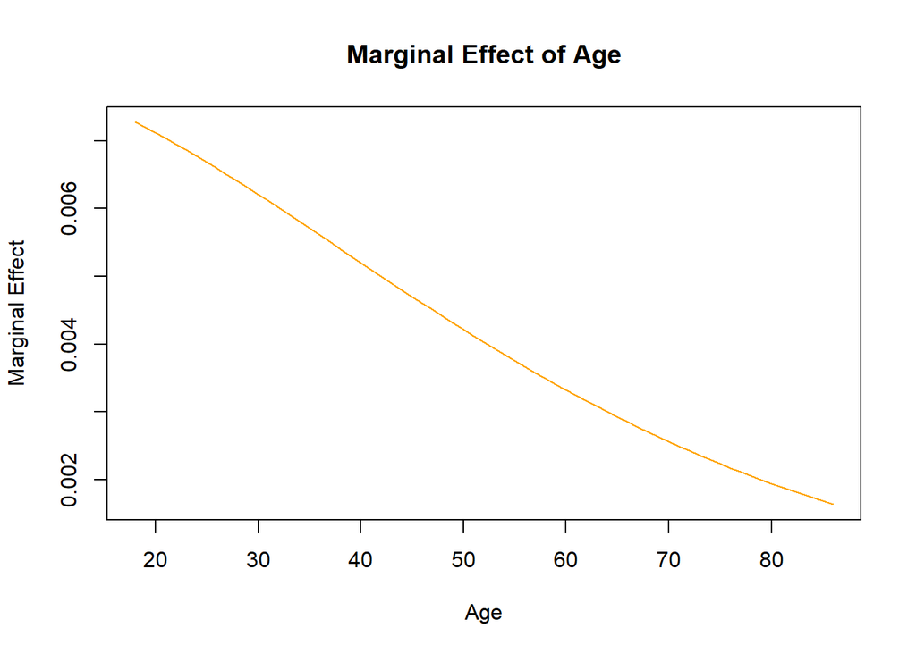

```r
# Calculate the marginal effect with the given formula
mgl_eff <- dlogis(av_person %*% coef(mlog)) * coef(mlog)["age"]

# Plot the results
plot(age_seq, mgl_eff, type = 'l', col = "orange",
     main = "Marginal Effect of Age",
     xlab = "Age", ylab = "Marginal Effect")
```

## **Additional Resources**

1. I found this [site](https://www.econometrics-with-r.org/11-2-palr.html) useful for plotting purposes. You can make the plots a bit fancier with the code here.